# Mixed Effects Models for Nonnormal Responses (ELMR Chapter 13)

Biostat 200C

Dr. Jin Zhou @ UCLA

May 18, 2023

```r
library(tidyverse)
library(faraway)
```

## Generalized linear mixed models (GLMM)

- So far we studied linear mixed models (LMM), where the responses are continuous and normally distributed. It is natural to extend LMM to handle nonnormally distributed responses.
- Recall that, in GLM, the distribution of $Y_i$ is from the exponential family of distributions of form
  $$f(y_i \mid \theta_i, \phi) = \exp \left[ \frac{y \theta_i -
  b(\theta_i)}{a(\phi)} + c(y_i, \phi) \right].$$
  If we use the **canonical link**, then
  $$\theta_i = g(\mu_i) = \eta_i,$$
  where $\mu_i = \mathbb{E} Y_i$. Now let
  $$\eta_i = \mathbf{x}_i^T \boldsymbol{\beta} + \mathbf{z}_i^T
  \boldsymbol{\gamma},$$
  where $\boldsymbol{\beta}$ is the fixed effects and $\boldsymbol{\gamma}$ is the random effects with density $h(\gamma \mid \boldsymbol{\Sigma})$. (Typically we assume multivariate normal with mean 0 and covariance $\boldsymbol{\Sigma}$.) Then the likelihood is
  $$L(\boldsymbol{\beta}, \phi, \boldsymbol{\Sigma}) = \prod_{i=1}^n \int
  f(y_i \mid \boldsymbol{\beta}, \phi, \boldsymbol{\gamma})
  h(\boldsymbol{\gamma} \mid \boldsymbol{\Sigma}) \, d \boldsymbol{\gamma}$$
  and the log-likelihood is
  $$\ell(\boldsymbol{\beta}, \phi, \boldsymbol{\Sigma}) = \sum_{i=1}^n \log
  \int f(y_i \mid \boldsymbol{\beta}, \phi, \boldsymbol{\gamma})
  h(\boldsymbol{\gamma} \mid \boldsymbol{\Sigma}) \, d
  \boldsymbol{\gamma}.$$
  This model, combining GLM and mixed effects model, is called the **generalized linear mixed effects model (GLMM)**.

## Overview of estimation and inference methods

- Estimation and inference of GLMM have been active research. We give an overview of a few commonly used methods.
- **Maximum likelihood estimate (MLE)** is obtained by maximizing the log-likelihood function. However, each iteration of the optimization algorithm needs to evaluate numerical integration, which quickly becomes infeasible when the dimension of random effects $\boldsymbol{\gamma}$ is large.
  - **Gauss-Hermite quadrature** can be used for numerical integration. It approximates the integral by a weighted sum of integrands at different knots. The more knots, the more accurate the approximation, but at higher computational expense.
  - **Laplace approximation** is a special case of Gauss-Hermite quadrature with only one knot. It is less accurate than Guass-Hermite quadrature but computationally cheaper.
- **Bayesian method** is another approach for estimation and inference of GLMM. It’s not covered in this course due to time constraint. Interested students can study ELMR Chapter 12.
- **Penalized quasi-likelihood (PQL)**. In the IRWLS (iteratively reweighted least squares) procedure for estimating the GLM, each iteration uses the pseudo-response or working response
  $$\mathbf{z}^{(t)} = \boldsymbol{\eta}^{(t)} + (\mathbf{W}^{(t)})^{-1}
  (\mathbf{y} - \widehat{\boldsymbol{\mu}}^{(t)}).$$
  It can be adapted to the mixed effects model. PQL has computational advantage but generally considered less accurate than other approaches.
- **Generalized estimation equations (GEE)**. To be discussed later.

## Binary response example

- `ctsib` data in EMLR studies the balance of 40 individuals.
  - Response: stability (1 = stable, 0 = instable).
  - Predictors: sex (binary), age (continuous), height (continuous), surface (binary, `norm` or `foam`), vision (factor, `open` or `closed` or `dome`).
  - Each subject is tested twice on a combination of `surface` and `vision`. 12 measurements per subject.

```r
ctsib <- as_tibble(ctsib) %>%
  mutate(stable = ifelse(CTSIB == 1, 1, 0)) %>%
  print(n = 24)
```

```
## # A tibble: 480 × 9
##    Subject Sex     Age Height Weight Surface Vision CTSIB stable
##      <int> <fct> <int>  <dbl>  <dbl> <fct>   <fct>  <int>  <dbl>
##  1       1 male     22    176   68.2 norm    open       1      1
##  2       1 male     22    176   68.2 norm    open       1      1
##  3       1 male     22    176   68.2 norm    closed     2      0
##  4       1 male     22    176   68.2 norm    closed     2      0
##  5       1 male     22    176   68.2 norm    dome       1      1
##  6       1 male     22    176   68.2 norm    dome       2      0
##  7       1 male     22    176   68.2 foam    open       2      0
##  8       1 male     22    176   68.2 foam    open       2      0
##  9       1 male     22    176   68.2 foam    closed     2      0
## 10       1 male     22    176   68.2 foam    closed     2      0
## 11       1 male     22    176   68.2 foam    dome       2      0
## 12       1 male     22    176   68.2 foam    dome       2      0
## 13       2 male     22    181   67.6 norm    open       1      1
## 14       2 male     22    181   67.6 norm    open       1      1
## 15       2 male     22    181   67.6 norm    closed     2      0
## 16       2 male     22    181   67.6 norm    closed     2      0
## 17       2 male     22    181   67.6 norm    dome       2      0
## 18       2 male     22    181   67.6 norm    dome       2      0
## 19       2 male     22    181   67.6 foam    open       2      0
## 20       2 male     22    181   67.6 foam    open       2      0
## 21       2 male     22    181   67.6 foam    closed     3      0
## 22       2 male     22    181   67.6 foam    closed     3      0
## 23       2 male     22    181   67.6 foam    dome       3      0
## 24       2 male     22    181   67.6 foam    dome       3      0
## # ℹ 456 more rows
```

```r
summary(ctsib)
```

```
##     Subject          Sex           Age            Height          Weight
##  Min.   : 1.00   female:240   Min.   :18.00   Min.   :142.0   Min.   : 44.20
##  1st Qu.:10.75   male  :240   1st Qu.:21.75   1st Qu.:166.8   1st Qu.: 60.65
##  Median :20.50                Median :25.50   Median :173.0   Median : 68.00
##  Mean   :20.50                Mean   :26.80   Mean   :172.1   Mean   : 71.14
##  3rd Qu.:30.25                3rd Qu.:33.00   3rd Qu.:180.2   3rd Qu.: 83.50
##  Max.   :40.00                Max.   :38.00   Max.   :190.0   Max.   :102.40
##  Surface       Vision        CTSIB           stable
##  foam:240   closed:160   Min.   :1.000   Min.   :0.0000
##  norm:240   dome  :160   1st Qu.:2.000   1st Qu.:0.0000
##             open  :160   Median :2.000   Median :0.0000
##                          Mean   :1.919   Mean   :0.2375
##                          3rd Qu.:2.000   3rd Qu.:0.0000
##                          Max.   :4.000   Max.   :1.0000
```

- Graphical summary.

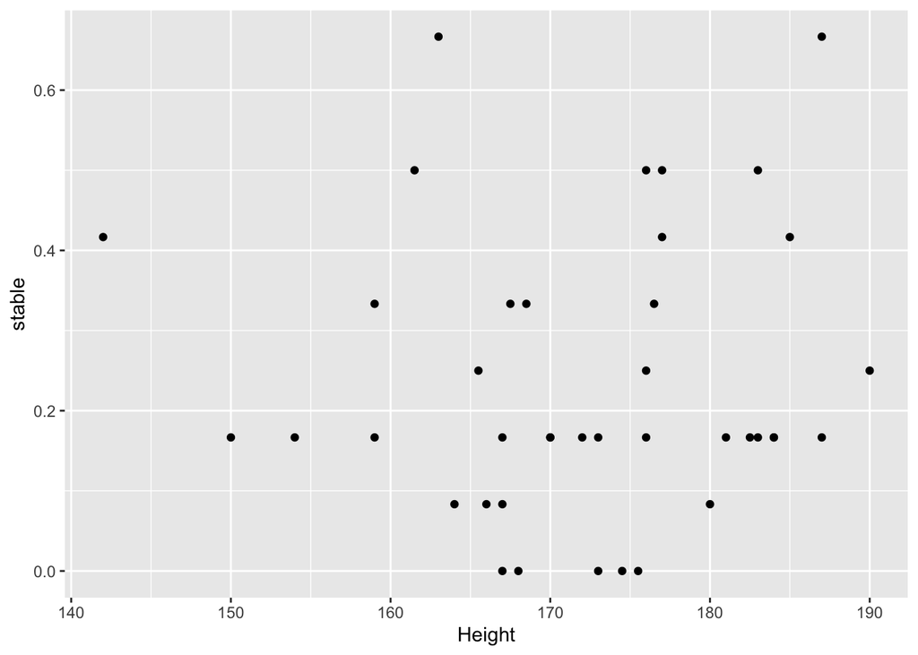

```r
subsum <- ctsib %>%
  group_by(Subject) %>%
  summarise(Height = Height[1],
            Weight = Weight[1],
            stable = mean(stable),
            Age    = Age[1],
            Sex    = Sex[1])
subsum %>%
  ggplot() +
  geom_point(mapping = aes(x = Height, y = stable))
```

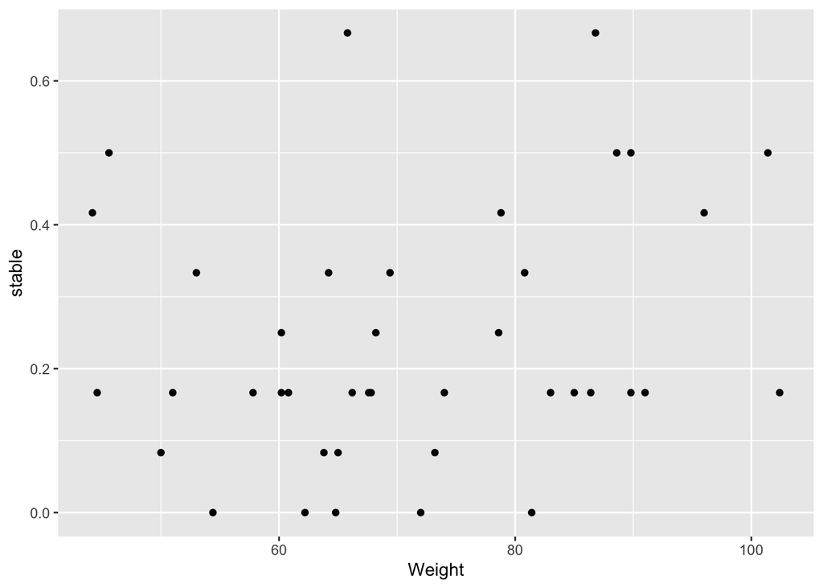

```r
subsum %>%
  ggplot() +
  geom_point(mapping = aes(x = Weight, y = stable))
```

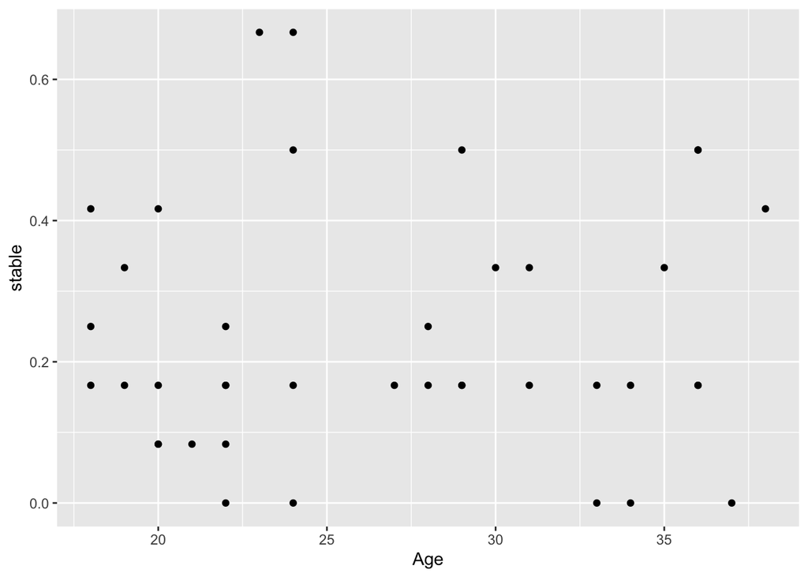

```r
subsum %>%
  ggplot() +
  geom_point(mapping = aes(x = Age, y = stable))
```

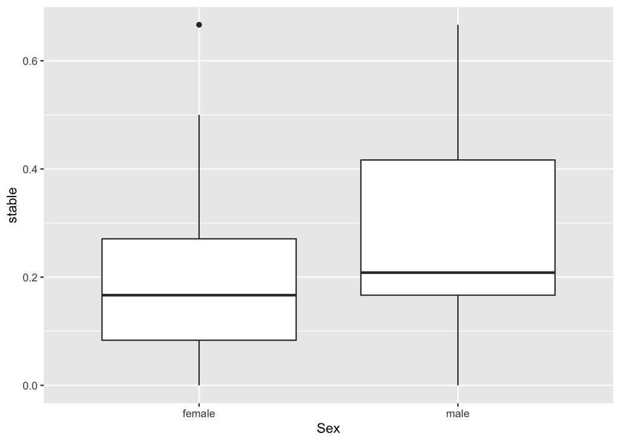

```r
subsum %>%
  ggplot() +
  geom_boxplot(mapping = aes(x = Sex, y = stable))
```

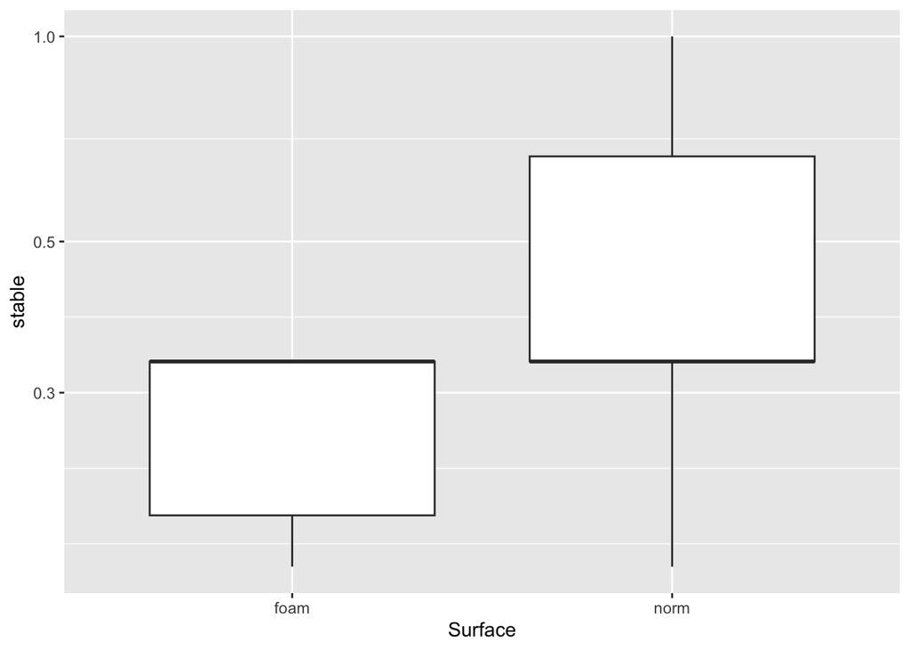

```r
ctsib %>%
  group_by(Subject, Surface) %>%
  summarize(stable = mean(stable)) %>%
  ggplot() +
  geom_boxplot(mapping = aes(x = Surface, y = stable)) +
  scale_y_log10()
```

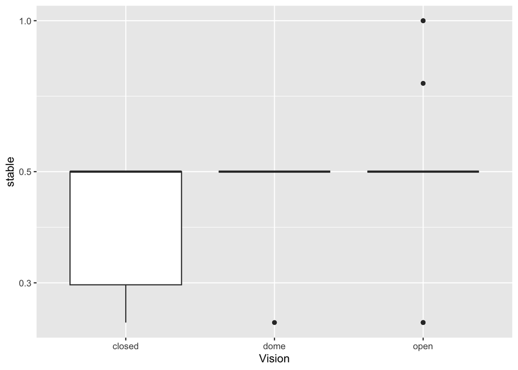

```r
ctsib %>%
  group_by(Subject, Vision) %>%
  summarize(stable = mean(stable)) %>%
  ggplot() +
  geom_boxplot(mapping = aes(x = Vision, y = stable)) +
  scale_y_log10()
```

- GLM analysis. What are the issues with the GLM here?

```r
gf <- glm(stable ~ Sex + Age + Height + Weight + Surface + Vision,
          family = binomial,
          data   = ctsib)
summary(gf)
```

```
##
## Call:
## glm(formula = stable ~ Sex + Age + Height + Weight + Surface +
##     Vision, family = binomial, data = ctsib)
##
## Deviance Residuals:
##      Min        1Q    Median        3Q       Max
## -2.28763  -0.54392  -0.13884  -0.05483   2.48130
##
## Coefficients:
##              Estimate Std. Error z value Pr(>|z|)
## (Intercept)  7.277449   3.803987   1.913 0.055734 .
## Sexmale      1.401577   0.516231   2.715 0.006627 **
## Age          0.002521   0.024307   0.104 0.917390
## Height      -0.096413   0.026837  -3.593 0.000327 ***
## Weight       0.043503   0.018002   2.417 0.015665 *
## Surfacenorm  3.967515   0.447179   8.872  < 2e-16 ***
## Visiondome   0.363753   0.383218   0.949 0.342516
## Visionopen   3.187501   0.416001   7.662 1.83e-14 ***
## ---
## Signif. codes:  0 '***' 0.001 '**' 0.01 '*' 0.05 '.' 0.1 ' ' 1
##
## (Dispersion parameter for binomial family taken to be 1)
##
##     Null deviance: 526.25  on 479  degrees of freedom
## Residual deviance: 295.20  on 472  degrees of freedom
## AIC: 311.2
##
## Number of Fisher Scoring iterations: 6
```

- GLMM analysis. We treat subjects as random. First, estimation by **Laplace approximation**.

```r
library(lme4)

modlap <-
  glmer(stable ~ Sex + Age + Height + Weight + Surface + Vision + (1 | Subject),
        family = binomial,
        data   = ctsib)
summary(modlap)
```

```
## Generalized linear mixed model fit by maximum likelihood (Laplace
##   Approximation) [glmerMod]
##  Family: binomial  ( logit )
## Formula: stable ~ Sex + Age + Height + Weight + Surface + Vision + (1 |
##     Subject)
##    Data: ctsib
##
##      AIC      BIC   logLik deviance df.resid
##    247.6    285.1   -114.8    229.6      471
##
## Scaled residuals:
##     Min      1Q  Median      3Q     Max
## -5.0149 -0.1266 -0.0176 -0.0005  4.8664
##
## Random effects:
##  Groups  Name        Variance Std.Dev.
##  Subject (Intercept) 8.197    2.863
## Number of obs: 480, groups:  Subject, 40
##
## Fixed effects:
##              Estimate Std. Error z value Pr(>|z|)
## (Intercept)  9.920823  13.091873   0.758   0.4486
## Sexmale      2.825340   1.746528   1.618   0.1057
## Age         -0.003642   0.079834  -0.046   0.9636
## Height      -0.151012   0.089829  -1.681   0.0927 .
## Weight       0.058925   0.061583   0.957   0.3387
## Surfacenorm  7.524402   1.164373   6.462 1.03e-10 ***
## Visiondome   0.683933   0.529835   1.291   0.1968
## Visionopen   6.321076   1.074732   5.882 4.06e-09 ***
## ---
## Signif. codes:  0 '***' 0.001 '**' 0.01 '*' 0.05 '.' 0.1 ' ' 1
##
## Correlation of Fixed Effects:
##             (Intr) Sexmal Age    Height Weight Srfcnr Visndm
## Sexmale      0.476
## Age         -0.170  0.097
## Height      -0.957 -0.392  0.050
## Weight       0.372 -0.366 -0.172 -0.560
## Surfacenorm  0.010  0.195 -0.010 -0.136  0.059
## Visiondome  -0.012  0.029  0.001 -0.026  0.015  0.115
## Visionopen   0.013  0.202 -0.007 -0.135  0.051  0.857  0.362
## optimizer (Nelder_Mead) convergence code: 0 (OK)
## Model failed to converge with max|grad| = 0.128017 (tol = 0.002, component 1)
## Model is nearly unidentifiable: large eigenvalue ratio
##  - Rescale variables?
```

- GLMM estimation by **Gauss-Hermite quadrature** with 25 knots.

```r
library(lme4)

modgh <-
  glmer(stable ~ Sex + Age + Height + Weight + Surface + Vision + (1 | Subject),
        nAGQ   = 25,
        family = binomial,
        data   = ctsib)
summary(modgh)
```

```
## Generalized linear mixed model fit by maximum likelihood (Adaptive
##   Gauss-Hermite Quadrature, nAGQ = 25) [glmerMod]
##  Family: binomial  ( logit )
## Formula: stable ~ Sex + Age + Height + Weight + Surface + Vision + (1 |
##     Subject)
##    Data: ctsib
##
##      AIC      BIC   logLik deviance df.resid
##    247.9    285.5   -115.0    229.9      471
##
## Scaled residuals:
##     Min      1Q  Median      3Q     Max
## -4.8841 -0.1386 -0.0197 -0.0007  4.9021
##
## Random effects:
##  Groups  Name        Variance Std.Dev.
##  Subject (Intercept) 7.194    2.682
## Number of obs: 480, groups:  Subject, 40
##
## Fixed effects:
##              Estimate Std. Error z value Pr(>|z|)
## (Intercept) 16.168911  12.719372   1.271   0.2037
## Sexmale      3.096705   1.696024   1.826   0.0679 .
## Age         -0.006669   0.076455  -0.087   0.9305
## Height      -0.192248   0.088937  -2.162   0.0306 *
## Weight       0.075156   0.059100   1.272   0.2035
## Surfacenorm  7.285350   1.055139   6.905 5.03e-12 ***
## Visiondome   0.675903   0.527363   1.282   0.2000
## Visionopen   6.088819   0.972383   6.262 3.81e-10 ***
## ---
## Signif. codes:  0 '***' 0.001 '**' 0.01 '*' 0.05 '.' 0.1 ' ' 1
##
## Correlation of Fixed Effects:
##             (Intr) Sexmal Age    Height Weight Srfcnr Visndm
## Sexmale      0.509
## Age         -0.166  0.094
## Height      -0.960 -0.429  0.047
## Weight       0.386 -0.324 -0.169 -0.570
## Surfacenorm  0.166  0.256 -0.013 -0.281  0.147
## Visiondome   0.007  0.034  0.000 -0.044  0.027  0.113
## Visionopen   0.169  0.265 -0.008 -0.280  0.138  0.829  0.382
## optimizer (Nelder_Mead) convergence code: 0 (OK)
## Model failed to converge with max|grad| = 0.289574 (tol = 0.002, component 1)
## Model is nearly unidentifiable: large eigenvalue ratio
##  - Rescale variables?
```

- GLMM estimation by PQL.

```r
library(MASS)

modpql <- glmmPQL(stable ~ Sex + Age + Height + Weight + Surface + Vision,
                  random = ~ 1 | Subject,
                  family = binomial,
                  data   = ctsib)
```

```
## iteration 1
```

```
## iteration 2
```

```
## iteration 3
```

```
## iteration 4
```

```
## iteration 5
```

```
## iteration 6
```

```
## iteration 7
```

```r
summary(modpql)
```

```
## Linear mixed-effects model fit by maximum likelihood
##   Data: ctsib
##   AIC BIC logLik
##    NA  NA     NA
##
## Random effects:
##  Formula: ~1 | Subject
##         (Intercept)  Residual
## StdDev:    3.060712 0.5906232
##
## Variance function:
##  Structure: fixed weights
##  Formula: ~invwt
## Fixed effects:  stable ~ Sex + Age + Height + Weight + Surface + Vision
##                 Value Std.Error  DF   t-value p-value
## (Intercept) 15.571494 13.498304 437  1.153589  0.2493
## Sexmale      3.355340  1.752614  35  1.914478  0.0638
## Age         -0.006638  0.081959  35 -0.080992  0.9359
## Height      -0.190819  0.092023  35 -2.073601  0.0455
## Weight       0.069467  0.062857  35  1.105155  0.2766
## Surfacenorm  7.724078  0.573578 437 13.466492  0.0000
## Visiondome   0.726464  0.325933 437  2.228873  0.0263
## Visionopen   6.485257  0.543980 437 11.921876  0.0000
##  Correlation:
##             (Intr) Sexmal Age    Height Weight Srfcnr Visndm
## Sexmale      0.488
## Age         -0.164  0.110
## Height      -0.963 -0.388  0.041
## Weight       0.368 -0.374 -0.168 -0.555
## Surfacenorm  0.051  0.116  0.023 -0.114  0.055
## Visiondome  -0.003  0.011  0.004 -0.017  0.011  0.087
## Visionopen   0.056  0.125  0.026 -0.116  0.049  0.788  0.377
##
## Standardized Within-Group Residuals:
##           Min            Q1           Med            Q3           Max
## -7.3825387626 -0.2333403344 -0.0233564299 -0.0004216629  9.9310682722
##
## Number of Observations: 480
## Number of Groups: 40
```

## Count response example

- `epilepsy` data in ELMR.
  - Response: `seizures` (number of seizures of each epilepsy patient).
  - Variables: `treat` (binary, 1 = treatment or 0 = control group), `expind` (binary, 0 = baseline or 1 = experiment phase), `timeadj` (length of phase).

```r
epilepsy <- as_tibble(epilepsy) %>%
  mutate(period = rep(0:4, 59),
         drug   = factor(c("placebo", "treatment"))[treat + 1],
         phase  = factor(c("baseline", "experiment"))[expind + 1]) %>%
  print()
```

```
## # A tibble: 295 × 9
##    seizures    id treat expind timeadj   age period drug    phase
##       <dbl> <int> <dbl>  <dbl>   <dbl> <dbl>  <int> <fct>   <fct>
##  1       11     1     0      0       8    31      0 placebo baseline
##  2        5     1     0      1       2    31      1 placebo experiment
##  3        3     1     0      1       2    31      2 placebo experiment
##  4        3     1     0      1       2    31      3 placebo experiment
##  5        3     1     0      1       2    31      4 placebo experiment
##  6       11     2     0      0       8    30      0 placebo baseline
##  7        3     2     0      1       2    30      1 placebo experiment
##  8        5     2     0      1       2    30      2 placebo experiment
##  9        3     2     0      1       2    30      3 placebo experiment
## 10        3     2     0      1       2    30      4 placebo experiment
## # ℹ 285 more rows
```

```r
summary(epilepsy)
```

```
##     seizures            id         treat            expind       timeadj
##  Min.   :  0.00   Min.   : 1   Min.   :0.0000   Min.   :0.0   Min.   :2.0
##  1st Qu.:  3.00   1st Qu.:15   1st Qu.:0.0000   1st Qu.:1.0   1st Qu.:2.0
##  Median :  6.00   Median :30   Median :1.0000   Median :1.0   Median :2.0
##  Mean   : 12.86   Mean   :30   Mean   :0.5254   Mean   :0.8   Mean   :3.2
##  3rd Qu.: 14.50   3rd Qu.:45   3rd Qu.:1.0000   3rd Qu.:1.0   3rd Qu.:2.0
##  Max.   :151.00   Max.   :59   Max.   :1.0000   Max.   :1.0   Max.   :8.0
##       age            period         drug            phase
##  Min.   :18.00   Min.   :0   placebo  :140   baseline  : 59
##  1st Qu.:22.00   1st Qu.:1   treatment:155   experiment:236
##  Median :28.00   Median :2
##  Mean   :28.85   Mean   :2
##  3rd Qu.:35.00   3rd Qu.:3
##  Max.   :57.00   Max.   :4
```

- Numerical summary. Is there any difference in the number of seizures per week in the placebo and treatment groups?

```r
epilepsy %>%
  group_by(drug, phase) %>%
  summarize(rate = mean(seizures / timeadj)) %>%
  xtabs(formula = rate ~ phase + drug)
```

```
##             drug
## phase         placebo treatment
##   baseline   3.848214  3.955645
##   experiment 4.303571  3.983871
```

- Graphical summary.

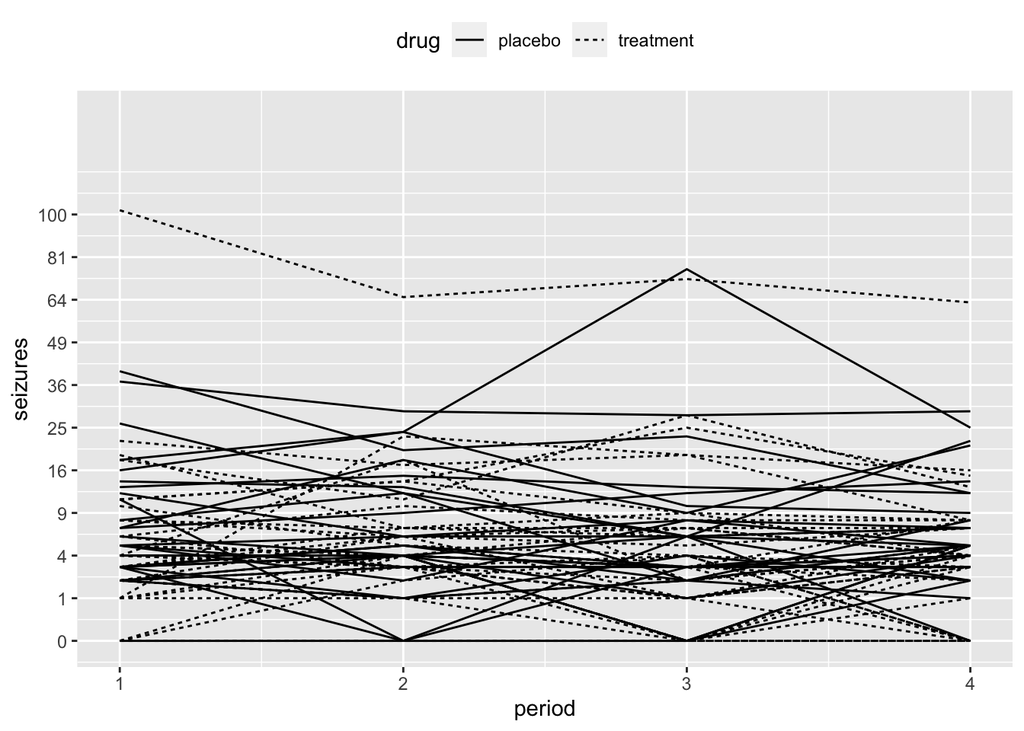

```r
epilepsy %>%
  ggplot() +
  geom_line(mapping = aes(x = period, y = seizures, linetype = drug, group = id)) +
  xlim(1, 4) +
  scale_y_sqrt(breaks = (0:10)^2) +
  theme(legend.position = "top", legend.direction = "horizontal")
```

```r
ratesum <- epilepsy %>%
  group_by(id, phase, drug) %>%
  summarize(rate = mean(seizures / timeadj))
```

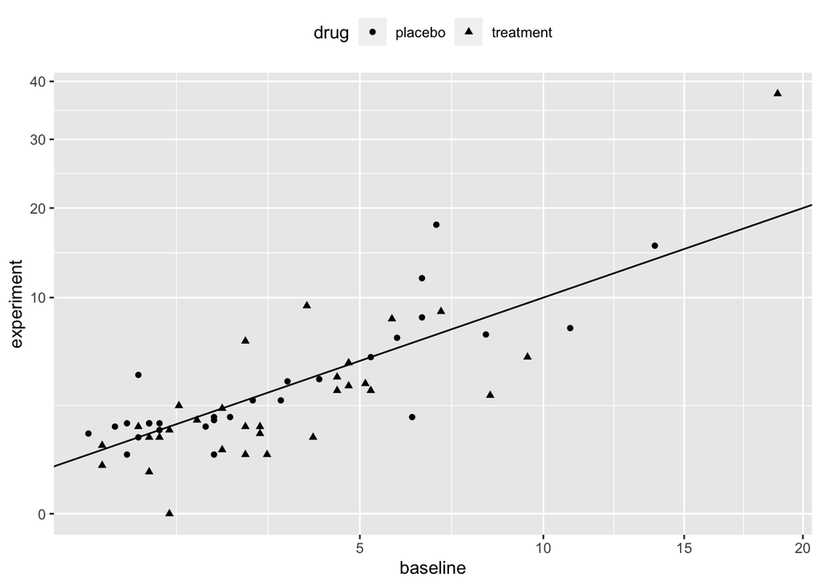

```r
spread(ratesum, phase, rate) %>%
  ggplot() +
  geom_point(mapping = aes(x = baseline, y = experiment, shape = drug)) +
  scale_x_sqrt() + scale_y_sqrt() +
  geom_abline(intercept = 0, slope = 1) +
  theme(legend.position = "top", legend.direction = "horizontal")
```

- In following analysis we remove patient 49, who seems to have unsually high rate of seizures.

```r
epilo <- filter(epilepsy, id != 49)
```

- We start with GLM analysis even though the model is not correct due to the grouping of observations.

```r
modglm <- glm(seizures ~ offset(log(timeadj)) + expind + treat + I(expind * treat),
              family   = poisson,
              data     = epilo)
summary(modglm)
```

```
##
## Call:
## glm(formula = seizures ~ offset(log(timeadj)) + expind + treat +
##     I(expind * treat), family = poisson, data = epilo)
##
## Deviance Residuals:
##     Min       1Q   Median       3Q      Max
## -5.4725  -2.3605  -1.0290   0.9001  14.0104
##
## Coefficients:
##                   Estimate Std. Error z value Pr(>|z|)
## (Intercept)        1.34761    0.03406  39.566  < 2e-16 ***
## expind             0.11184    0.04688   2.386    0.017 *
## treat             -0.10682    0.04863  -2.197    0.028 *
## I(expind * treat) -0.30238    0.06971  -4.338 1.44e-05 ***
## ---
## Signif. codes:  0 '***' 0.001 '**' 0.01 '*' 0.05 '.' 0.1 ' ' 1
##
## (Dispersion parameter for poisson family taken to be 1)
##
##     Null deviance: 2485.1  on 289  degrees of freedom
## Residual deviance: 2411.5  on 286  degrees of freedom
## AIC: 3449.7
##
## Number of Fisher Scoring iterations: 5
```

- GLMM analysis by Gauss-Hermite quadrature with 25 knots.

```r
library(lme4)

modgh <- glmer(seizures ~ offset(log(timeadj)) + expind + treat + I(expind * treat) + (1 | id),
               nAGQ     = 25,
               family   = poisson,
               data     = epilo)
summary(modgh)
```

```
## Generalized linear mixed model fit by maximum likelihood (Adaptive
##   Gauss-Hermite Quadrature, nAGQ = 25) [glmerMod]
##  Family: poisson  ( log )
## Formula: seizures ~ offset(log(timeadj)) + expind + treat + I(expind *
##     treat) + (1 | id)
##    Data: epilo
##
##      AIC      BIC   logLik deviance df.resid
##    877.7    896.1   -433.9    867.7      285
##
## Scaled residuals:
##     Min      1Q  Median      3Q     Max
## -3.8724 -0.8482 -0.1722  0.5697  9.8941
##
## Random effects:
##  Groups Name        Variance Std.Dev.
##  id     (Intercept) 0.515    0.7176
## Number of obs: 290, groups:  id, 58
##
## Fixed effects:
##                    Estimate Std. Error z value Pr(>|z|)
## (Intercept)        1.035998   0.141256   7.334 2.23e-13 ***
## expind             0.111838   0.046877   2.386    0.017 *
## treat             -0.008152   0.196525  -0.041    0.967
## I(expind * treat) -0.302387   0.069714  -4.338 1.44e-05 ***
## ---
## Signif. codes:  0 '***' 0.001 '**' 0.01 '*' 0.05 '.' 0.1 ' ' 1
##
## Correlation of Fixed Effects:
##             (Intr) expind treat
## expind      -0.175
## treat       -0.718  0.126
## I(xpnd*trt)  0.118 -0.672 -0.173
```

- GLMM estimation by PQL.

```r
library(MASS)

modpql <- glmmPQL(seizures ~ offset(log(timeadj)) + expind + treat + I(expind * treat),
                  random = ~ 1 | id,
                  family = poisson,
                  data   = epilo)
```

```
## iteration 1
```

```
## iteration 2
```

```
## iteration 3
```

```
## iteration 4
```

```
## iteration 5
```

```r
summary(modpql)
```

[output not shown]

## GEE (generalized estimation equation)

- The quasi-likelihood (quasi-binomial, quasi-Poisson, etc) approach can be generalized to handle correlated, nonnormal responses.
- Let $\mathbf{Y}_i$ be the response vector of $i$-th individual.
  $$\begin{eqnarray*}
  \mathbb{E} \mathbf{Y}_i &=& \boldsymbol{\mu}_i \\
  g(\boldsymbol{\mu}_i) &=& \mathbf{X}_i \boldsymbol{\beta} \\
  \mathbf{V}_i &=& \text{Var}(\mathbf{Y}_i) = \phi
  \mathbf{A}_i^{1/2} \mathbf{R}_i(\boldsymbol{\alpha}) \mathbf{A}_i^{1/2},
  \end{eqnarray*}$$
  where $\mathbf{A}_i = \text{diag}(a(\boldsymbol{\mu}))$ captures the individual variances and $\mathbf{R}_i(\boldsymbol{\alpha})$ is a **working correlation matrix**.
- Commonly used working correlation are
  - compound symmetry, or equicorrelation, or exchangeable correlation:
    $$\mathbf{R}(\rho) = \begin{pmatrix}
    1 & \rho & \cdots & \rho \\
    \rho & 1 & & \rho \\
    \vdots & & \ddots & \vdots \\
    \rho & \rho & \cdots & 1
    \end{pmatrix}$$
  - Autoregressive model:
    $$\mathbf{R}(\rho) = \begin{pmatrix}
    1 & \rho & \rho^2 & \cdots & \rho^{n-1} \\
    \rho & 1 & \rho & & \rho^{n-2} \\
    \rho^2 & \rho & 1 & & \vdots \\
    \vdots & & & \ddots & \\
    \rho^{n-1} & \cdots & & \rho & 1
    \end{pmatrix}$$
  - Unstructured correlation matrix
- Given estimates of $\phi$ and $\boldsymbol{\alpha}$, we solve the **estimation equation**
  $$\sum_i [D_{\boldsymbol{\beta}} \boldsymbol{\mu}_i(\boldsymbol{\beta})]^T
  \mathbf{V}_i^{-1}(\mathbf{Y}_i - \boldsymbol{\mu}_i) = \mathbf{0}.$$
- Let’s revisit the `ctsib` (stability) data set. We use the exchangeable correlation, or equivalently, compound symmetry. Standard errors and Wald test are constructed using the sandwich estimators. $\boldsymbol{\beta}$ estimates in GEE are about half the size of those from GLMM. The `scale.fix = TRUE` instructs the function `geeglm` not estimate the dispersion parameter $\phi$, since for binary response the dispersion is always 1.

```r
library(geepack)

modgeep <- geeglm(stable    ~ Sex + Age + Height + Weight + Surface + Vision,
                  id        = Subject,
                  corstr    = "exchangeable",
                  scale.fix = TRUE,
                  data      = ctsib,
                  family    = binomial(link = "logit"))
summary(modgeep)
```

```
##
## Call:
## geeglm(formula = stable ~ Sex + Age + Height + Weight + Surface +
##     Vision, family = binomial(link = "logit"), data = ctsib,
##     id = Subject, corstr = "exchangeable", scale.fix = TRUE)
##
##  Coefficients:
##             Estimate  Std.err   Wald Pr(>|W|)
## (Intercept)  8.62332  5.91992  2.122   0.1452
## Sexmale      1.64488  0.90347  3.315   0.0687 .
## Age         -0.01205  0.04802  0.063   0.8019
## Height      -0.10211  0.04239  5.801   0.0160 *
## Weight       0.04365  0.03399  1.649   0.1991
## Surfacenorm  3.91632  0.56682 47.738 4.87e-12 ***
## Visiondome   0.35888  0.40403  0.789   0.3744
## Visionopen   3.17990  0.46063 47.657 5.08e-12 ***
## ---
## Signif. codes:  0 '***' 0.001 '**' 0.01 '*' 0.05 '.' 0.1 ' ' 1
##
## Correlation structure = exchangeable
## Scale is fixed.
##
##   Link = identity
##
## Estimated Correlation Parameters:
##       Estimate Std.err
## alpha   0.2185 0.04467
## Number of clusters:   40  Maximum cluster size: 12
```

- Let’s revisit the `epilepsy` data set.

```r
modgeep <- geeglm(seizures ~ offset(log(timeadj)) + expind + treat + I(expind*treat),
                  id       = id,
                  family   = poisson,
                  corstr   = "ar1",
                  data     = epilepsy,
                  subset  = (id != 49))
summary(modgeep)
```

```
##
## Call:
## geeglm(formula = seizures ~ offset(log(timeadj)) + expind + treat +
##     I(expind * treat), family = poisson, data = epilepsy, subset = (id !=
##     49), id = id, corstr = "ar1")
##
##  Coefficients:
##                   Estimate Std.err  Wald Pr(>|W|)
## (Intercept)         1.3138  0.1616 66.10  4.4e-16 ***
## expind              0.1509  0.1108  1.86    0.173
## treat              -0.0797  0.1983  0.16    0.688
## I(expind * treat)  -0.3987  0.1745  5.22    0.022 *
## ---
## Signif. codes:  0 '***' 0.001 '**' 0.01 '*' 0.05 '.' 0.1 ' ' 1
##
## Correlation structure = ar1
## Estimated Scale Parameters:
##
##             Estimate Std.err
## (Intercept)     10.6    2.35
##   Link = identity
##
## Estimated Correlation Parameters:
##       Estimate Std.err
## alpha    0.783  0.0519
## Number of clusters:   58  Maximum cluster size: 5
```